# Goodness of fit with large Sample size

Robersy Sanchez https://genomaths.github.io/ Department of Biology and Plant Science. Pennsylvania State University, University Park, PA 16802

11 February 2019

Abstract

The goodness of fit (GOF) tests frequently fail with real datasets when the sample size goes beyond 100. This issue is critical when working with experimental data where enviromental random noise cannot be prevented. Fortunately, permutation and Monte Carlo approaches for GOF could help to confront the issue. Herein, two examples with simulated data are presented.

# 1 Install and loading the R packages needed for the computation

To run a Monte Carlo (MC) approach for GOF we will install the R package usefr and its dependences from GitHub:

```r
source("https://bioconductor.org/biocLite.R")
biocLite('BiocParallel')

install.packages(c("minpack.lm", "numDeriv", "devtools", "ggplot2", "gridExtra"),
                 dependencies=TRUE)

devtools::install_git("https://github.com/genomaths/usefr.git")
```

Next, to load the packages that are needed for this example:

```r
suppressMessages(library(ggplot2))
suppressMessages(library(gridExtra))
suppressMessages(library(usefr))
```

# 2 Example 1

Let us simulate random samples from a specified Normal and Weibull distributions. To make reproducible this example, we set a seed.

```r
set.seed(1)
x1 = rnorm(10000, mean = 1.5, sd = 2)
x2 = rweibull(10000, shape = 0.5, scale = 1.2)

dt <- data.frame(x1 = x1, x2 = x2)
```

## 2.1 The histograms and density plots of the given Normal and Weibull distributions

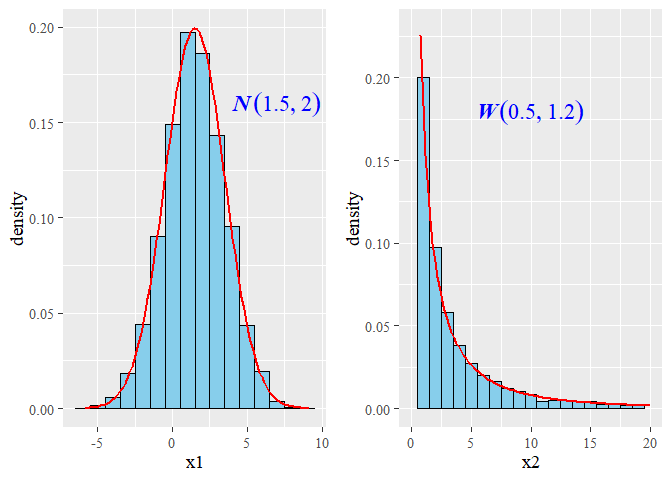

```r
p1 <- ggplot(data = dt, aes(x1)) +
  geom_histogram(data = dt, aes(y=..density..), binwidth = 1,
                 colour = "black", fill = "skyblue", na.rm=TRUE) +
  stat_function(fun = dnorm, n = 101, col = "red",
                args = list(mean = 1.5, sd = 2), size = 1) +
  theme_gray(base_family = "serif", base_size = 14) +
  annotate(geom = "text", x = 7, y = 0.16, size = 6,
           label = 'bolditalic(N(1.5,2))',
           family = "serif", color = "blue", parse = TRUE)


p2 <- ggplot(data = dt, aes(x2)) +
  geom_histogram(data = dt, aes(y=..density..), binwidth = 1,
                 colour = "black", fill = "skyblue", na.rm=TRUE) +
  xlim(0,20) + ylim(0,0.23) +
  stat_function(fun = dweibull, n = 101, col = "red",
                args = list(shape = 0.5, scale = 1.2), size = 1) +
  theme_gray(base_family = "serif", base_size = 14) +
  annotate(geom = "text", x = 10, y = 0.18, size = 6,
           label = 'bolditalic(W(0.5, 1.2))',
           family = "serif", color = "blue", parse = TRUE)

grid.arrange(p1, p2, nrow = 1)
```

The bell shape, typical of the normal distribution, is clear. Many people are not familiar with the Weibull distribution. The decay observed in the Weibull distribution presented in the figure is typically found for the for information divergences of DNA methylation levels, in humans and in plants (Sanchez and Mackenzie 2016).

# 3 The Monte Carlo GOF test

The test is performed with function *mcgoftest* from the R package *usefr*

```r
mcgoftest(x1, cdf = pnorm, pars = c(1.5, 2), num.sampl = 500,
          sample.size = 1000, num.cores = 1)
```

```
## *** Monte Carlo KS test,..
```

```
## mc_p.value  KS.stat.D KS_p.value
##  0.5908184  0.2534276  0.0000000
```

Kolmogorov-Smirnov (KS) test rejects the *Null Hypothesis*: *KS_p.value* $\simeq$ 0. According with KS test there is not enough statistical evidence to support the null hypothesis that the observed values of variable *x1* follow a normal distribution with mean 1.5 and standard deviation 2. This looks paradoxical if we take into account that this sample was generated using the theoretical distribution. The fact is that computer algorithms to generate random numbers are not perfect and, so far, the numerical algorithms can only generate pseudo-random numbers, which mostly follow the theoretical distribution. The Monte Carlo sampling approach, however, does not reject the *Null Hypothesis*: *mc_p.value* = 0.5908184. However, the failure of KS test would be the result of more deep mathematical-philosophical issues.

The testing for the Weibull distribution yields similar results

```r
mcgoftest(x1, cdf = pweibull, pars = c(shape = 0.5, scale = 1.2), num.sampl = 500,
          sample.size = 1000, num.cores = 1)
```

```
## *** Monte Carlo KS test,..
```

```
## mc_p.value  KS.stat.D KS_p.value
##  0.6027944  0.3042703  0.0000000
```

MC KS test does not reject the null hypothesis that variable x comes from Weibull(x|shape = 0.5, scale = 1.2), while the standard Kolmogorov-Smirnov test rejects the Null Hypothesis.

# References

Sanchez, Robersy, and Sally A. Mackenzie. 2016. “Information Thermodynamics of Cytosine DNA Methylation.” Edited by Barbara Bardoni. *PLOS ONE* 11 (3). Public Library of Science: e0150427. doi:10.1371/journal.pone.0150427.